# BCB420: Assignment 2

Differential Gene expression and Preliminary Over-Representation Analysis of Down Syndrome vs Control L3 and L5 Pyramidal Neurons

Clare Gillis

03/12/2025

# 1 Introduction

Down Syndrome (DS) is a genetically complex condition resulting from the triplication of chromosome 21. Roughly 1 in every 700 babies born has DS. DS individuals have a variety of phenotypic abnormalities but are notably coginitively impaired. Alzheimer’s Disease (AD) pathology is universal among individuals with DS and onset generally occurs around their mid-30s (Melissa J. Alldred et al. 2024b). To investigate the connection between DS and AD pathology, Alldred et al. performed bulk RNA Seq of layer 3 (L3) and 5 (L5) pyramidal neurons of individuals with Down Syndrome (DS) compared to control brains (Melissa J. Alldred et al. 2024b).

I have [previously cleaned and normalized](https://github.com/bcb420-2025/Clare_Gillis/blob/main/A1_ClareGillis/ClareGillis.Rmd) the RNASeq dataset created by Alldred et al. which is available at GEO accession GSE251939. Duplicate genes were removed, technical replicates were combined, each gene was mapped to a HUGO gene symbol, and the dataset was normalized using CMM and TMM. The resulting expression dataset covers 18027 genes.

The analysis below focuses on differential gene expression of the cleaned and normalized data, followed by a thresholded over-representation analysis of the genes in question.

We will begin by importing the necessary packages for our analysis. We will use GEOquery (Davis and Meltzer 2007) to retrieve information about each sample (diagnosis, layer, etc), edgeR (Chen, Lun, and Smyth 2016) to model differential gene expression in our data, ggplot2 (Wickham 2016) to visualize the number of differentially expressed genes, circlize (Gu 2022a) & ComplexHeatmap (Gu 2023) to display our differential expression data as a heatmap, and GSA (Efron and Tibshirani 2022) & gprofiler2 (Kolberg et al. 2020) to perform a thresholded over expression analysis.

```r
# ==================
# Install Required Packages
# ==================
if (!requireNamespace("BiocManager", quietly = TRUE))
  install.packages("BiocManager")

if (!requireNamespace("GEOquery", quietly = TRUE)) {
  BiocManager::install("GEOquery")
}

if (!requireNamespace("edgeR", quietly = TRUE)) {
  BiocManager::install("edgeR")
}

if (!requireNamespace("biomaRt", quietly = TRUE)) {
  BiocManager::install("biomaRt")
}

if (!requireNamespace("kableExtra", quietly = TRUE)){
  install.packages("kableExtra")
}

if (!requireNamespace("R.utils", quietly = TRUE)){
  install.packages("R.utils")
}

if (!requireNamespace("ComplexHeatmap", quietly = TRUE)){
  install.packages("ComplexHeatmap")
}

if (!requireNamespace("circlize", quietly = TRUE)){
  install.packages("circlize")
}

if (!requireNamespace("gprofiler2", quietly = TRUE)){
  install.packages("gprofiler2")
}

if (!requireNamespace("GSA", quietly = TRUE)){
  install.packages("GSA")
}

if (!requireNamespace("ggplot2", quietly = TRUE)){
  install.packages("ggplot2")
}

library(ggplot2)
library(gprofiler2)
library(GSA)
library(circlize)
library(ComplexHeatmap)
library(R.utils)
library(kableExtra)
library(edgeR)
library(GEOquery)
library(knitr)
library(biomaRt)
```

# 2 Differential Gene Expression

## 2.1 Extract Data

We first import the cleaned, normalized count data created for [Assignment 1](https://github.com/bcb420-2025/Clare_Gillis/blob/main/A1_ClareGillis/ClareGillis.Rmd), then extract the metadata for each sample (diagnosis, layer, etc) from GEO accession GSE251939 using GEOquery (Davis and Meltzer 2007).

```r
# ==================
# Extract the data
# ==================

# We begin by extracting the normalized clean counts matrix created for A1

norm_counts_clean <- read.table(file.path(getwd(), "normalized_filtered_RSEM_counts.txt"),
                                header = TRUE,
                                sep = "\t",
                                quote = "",
                                check.names = FALSE)

# Make the data into a matrix
expressionMatrix <- as.matrix(norm_counts_clean)
```

```r
# ==================
# Extract samples and their categorical information
# ==================

data_set_geoid <- "GSE251939"
gse <- GEOquery::getGEO(data_set_geoid ,GSEMatrix=FALSE)

# Extract all samples
list_of_samples <- gse@gsms

# Get the name and characteristics of each sample
sample_type <- do.call(rbind, lapply(list_of_samples,
                                     FUN=function(x){
                                       c(x@header$title,
                                         x@header$characteristics_ch1)
                                       }
                                     )
                       )
colnames(sample_type) <- c("title", "cell type", "diagnosis", "layer")
sample_type[,"cell type"] <- gsub(sample_type[, "cell type"],
                                  pattern = "cell type: ",
                                  replacement = "")
sample_type[,"diagnosis"] <- gsub(sample_type[, "diagnosis"],
                                  pattern = "diagnosis: ",
                                  replacement = "")
sample_type[,"layer"] <- gsub(sample_type[, "layer"],
                                  pattern = "layer: ",
                                  replacement = "")

# Extract sample IDs from the title (ex. 'h270' from 'FCPN, Layer3, CTR, h270B_Layer3')
redundant_sample_type_dt <- data.table::data.table(sample_type)
redundant_sample_type_dt[, "sampleID"] <- sub(".*(h\\d+).*", "\\1", redundant_sample_type_dt$title)

# Remove all technical replicates
sample_type_dt <- redundant_sample_type_dt[, .SD[1], by = .(sampleID, layer)]
```

## 2.2 Model and Predict Differential Expression

To perform a differential gene expression analysis, we next model the cleaned data, taking into account diagnosis, layer, and the interaction between these two features. After fitting the model to our data, we use the quasi likelihood method to predict differential expression of the genes in our dataset between DS and control samples. P-values are corrected using the Benjamini-Hochberg (BH) method (Srinivasan et al. 2013) to control the False Discovery Rate (FDR) and minimize the number of falsely identified differentially expressed genes.

```r
# ==================
# Create the model for the differential expression analysis and fit it to our data
# ==================

# Create a model to predict differential expression in our dataset that takes
# into account cell layer and diagnosis (DS vs CTR)
model_design_pat <- model.matrix(~ sample_type_dt$layer +
                                   sample_type_dt$diagnosis +
                                   sample_type_dt$layer:sample_type_dt$diagnosis
                                 )

# Use the edgeR package to fit the model to our expression data
d <- edgeR::DGEList(counts=expressionMatrix, group=sample_type_dt$diagnosis)
d <- edgeR::estimateDisp(d, model_design_pat)
fit <- edgeR::glmQLFit(d, model_design_pat)

# Use quasi likelihood method to calculate differential expression
qlf.ds_vs_ctr <- edgeR::glmQLFTest(fit, coef = 'sample_type_dt$diagnosisDS')

# Display the top differentially expressed genes and perform a BH FDR correction
kable(topTags(qlf.ds_vs_ctr)$table,
      type="html",
      p.adjust.method = "BH",
      row.names = TRUE,
      caption = "TABLE 1: Top differentially expressed genes in our dataset. logFC = log2 fold change, logCPM = log2 counts per million, F = F-statistic from quasi likelihood test, PValue = raw P value, FDR = Benjamin-Hochberg FDR corrected P values.
      ") %>% kable_styling(full_width = FALSE, position = "center")
```

TABLE 1: Top differentially expressed genes in our dataset. logFC = log2 fold change, logCPM = log2 counts per million, F = F-statistic from quasi likelihood test, PValue = raw P value, FDR = Benjamin-Hochberg FDR corrected P values.

|  | logFC | logCPM | F | PValue | FDR |
| --- | --- | --- | --- | --- | --- |
| CD74 | 2.9611850 | 5.164511 | 156.61368 | 0 | 0 |
| PTTG1IP | 1.7261030 | 5.255675 | 153.43077 | 0 | 0 |
| SERPINA3 | 7.4422037 | 4.027760 | 117.59767 | 0 | 0 |
| OPRK1 | 2.7052396 | 4.391044 | 117.15873 | 0 | 0 |
| FCGBP | 4.1166462 | 4.623952 | 103.59867 | 0 | 0 |
| SPON2 | -2.2908654 | 3.509559 | 93.53183 | 0 | 0 |
| CD44 | 5.3267265 | 3.241704 | 92.84352 | 0 | 0 |
| C4A | 2.9513256 | 4.505552 | 91.26126 | 0 | 0 |
| RPS6KA2 | 0.9963946 | 6.349679 | 91.11109 | 0 | 0 |
| IFITM2 | 3.6826351 | 2.387415 | 90.79412 | 0 | 0 |

The top results show PValue and FDR values of 0 - in reality these are not 0 but are just very low and the limitations of R cause them to be shown as 0. These values indicate that many genes are very significantly differentially expressed between DS and control samples.

# 3 BH Correction

We will normalize our data using a Benjamin-Hochberg test to reduce the false discovery rate. This test is less stringent than the Bonferroni test but maintains statistical power for removing false positives (Srinivasan et al. 2013).

```r
# ==================
# Perform a BH correction
# ==================
qlf_output_hits <- edgeR::topTags(qlf.ds_vs_ctr,
                                  sort.by = "PValue",
                                  n = nrow(norm_counts_clean),
                                  adjust.method = "BH")

write.table(qlf_output_hits$table, file = "/home/rstudio/projects/A3/diff_expr_data.txt", sep = "\t",
            quote = FALSE, row.names = TRUE, col.names = NA)

write.table(sample_type_dt,
            file = "/home/rstudio/projects/A3/sample_types.txt",
            sep = "\t",
            quote = FALSE,
            row.names = TRUE,
            col.names = NA
            )

num_sig_preBH <- length(which(qlf_output_hits$table$PValue < 0.05 &
                                abs(qlf_output_hits$table$logFC) > 1))
num_sig_postBH <- length(which(qlf_output_hits$table$FDR < 0.05 &
                                 abs(qlf_output_hits$table$logFC) > 1))

cat(paste("Number of significantly differentially differentially expressed genes before BH correction: ", num_sig_preBH, "\n"))
```

```
## Number of significantly differentially differentially expressed genes before BH correction:  2623
```

```r
cat(paste("Number of significantly differentially differentially expressed genes after BH correction: ", num_sig_postBH, "\n"))
```

```
## Number of significantly differentially differentially expressed genes after BH correction:  1102
```

## 3.1 Visualization

### 3.1.1 Volcano Plot

We can visualize the number of significantly upregulated and downregulated genes using a volcano plot. We will plot each gene by the -log10 of its FDR corrected P value and log2 fold change. Significantly upregulated genes (FDR corrected P value < 0.05 and log fold change > 1) are colored red while significantly downregulated genes (FDR corrected P value < 0.05 and log fold change < -1) are colored blue. All other genes are colored grey.

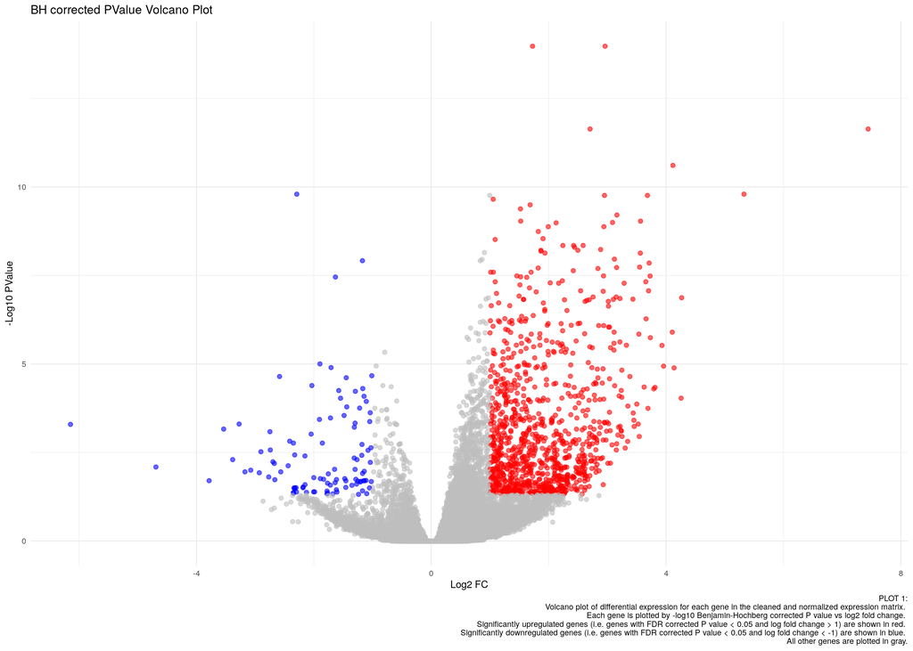

```r
# ==================
# Volcano Plot
# ==================

volcano_data <- qlf_output_hits$table
volcano_data$logFDR <- -log10(volcano_data$FDR)  # Calculate -log10(FDR corrected p-value)

# Define a threshold for significance (e.g., FDR < 0.05 and logFC > 1)
threshold_FDR <- 0.05
threshold_logFC <- 1

# Create a column for significance (significant if p-value < 0.05 and logFC > 1 or < -1)
volcano_data$significant <- with(volcano_data,
                                 (FDR < threshold_FDR) & (abs(logFC) > threshold_logFC))

# Create a column for coloring based on the direction of logFC
volcano_data$color <- with(volcano_data,
                           ifelse(significant & logFC > 0, "red",
                                  ifelse(significant & logFC < 0, "blue", "gray")))

# Plot FDR corrected values on volcano plot
ggplot2::ggplot(volcano_data, aes(x = logFC, y = logFDR, color = color)) +
                geom_point(alpha = 0.6, size = 2) +
                theme_minimal() +
                scale_color_manual(values = c("blue", "gray", "red")) +
                labs(title = "BH corrected PValue Volcano Plot",
                     x = "Log2 FC",
                     y = "-Log10 PValue",
                     caption =
                       "PLOT 1:
                     Volcano plot of differential expression for each gene in the cleaned and normalized expression matrix.
                     Each gene is plotted by -log10 Benjamin-Hochberg corrected P value vs log2 fold change.
                     Significantly upregulated genes (i.e. genes with FDR corrected P value < 0.05 and log fold change > 1) are shown in red.
                     Significantly downregulated genes (i.e. genes with FDR corrected P value < 0.05 and log fold change < -1) are shown in blue.
                     All other genes are plotted in gray.") +
                theme(legend.position = "none")
```

There are many significantly differentially expressed genes in our dataset. Notably, there are more upregulated than downregulated genes which is to be expected in DS. Since DS is caused by the triplication of chromosome 21, we would expect higher levels of genes from chromosome 21 in DS individuals than controls.

### 3.1.2 Heatmap

Below we display our differential gene expression data as a heatmap clustered by expression.

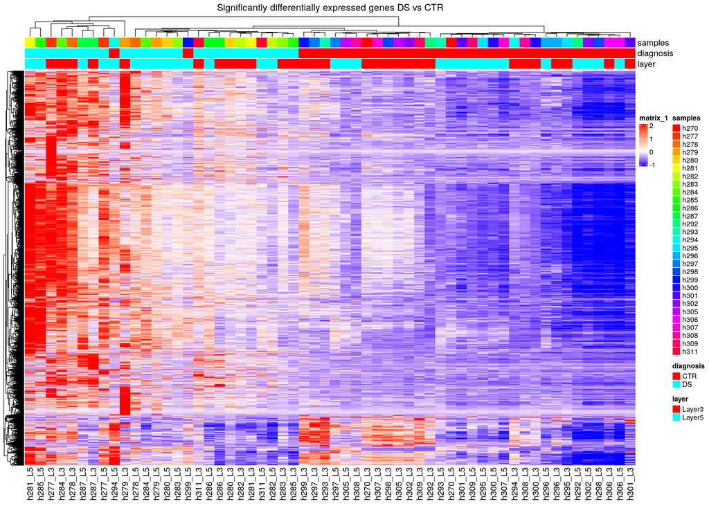

```r
# ==================
# Create a heatmap of our differential gene expression data including data clustering
# ==================

# Get the significanly differentially expressed genes
top_hits <- rownames(qlf_output_hits$table)[qlf_output_hits$table$FDR < 0.05]
heatmap_matrix_tophits <- t(
  scale(
    t(expressionMatrix[
      which(rownames(expressionMatrix) %in% top_hits),]
      )
    )
)

# Calculate 5th and 95th percentiles
percentile_5 <- quantile(heatmap_matrix_tophits, 0.05)
percentile_95 <- quantile(heatmap_matrix_tophits, 0.95)

# Define color scale based on percentiles
if (percentile_5 == 0) {
  heatmap_col <- circlize::colorRamp2(c(percentile_5, percentile_95),
                                      c("white", "red"))
} else {
  heatmap_col <- circlize::colorRamp2(c(percentile_5, 0, percentile_95),
                                       c("blue", "white", "red"))
}


# Add annotations to the heatmap to show data clustering

# Assign a color to each sample
unique_samples <- unique(sample_type_dt$sampleID)
unique_sample_colors <- rainbow(n = length(unique_samples))
names(unique_sample_colors) <- unique_samples

# Assign a color to each diagnosis
unique_diagnosis <- unique(sample_type_dt$diagnosis)
unique_diagnosis_colors <- rainbow(n = length(unique_diagnosis))
names(unique_diagnosis_colors) <- unique_diagnosis

# Assign a color to each layer
unique_layer <- unique(sample_type_dt$layer)
unique_layer_colors <- rainbow(n = length(unique_layer))
names(unique_layer_colors) <- unique_layer

# Create an annotation to color code each column by sample, diagnosis, and layer
ha_pat <- ComplexHeatmap::HeatmapAnnotation(
  df = data.frame(
  samples = sample_type_dt$sampleID,
  diagnosis = sample_type_dt$diagnosis,
  layer = sample_type_dt$layer),
  col = list(
    samples = unique_sample_colors,
    diagnosis = unique_diagnosis_colors,
    layer = unique_layer_colors),
  show_legend = TRUE)

# Create a color coded heatmap of the differential expression data, clustered
# as much as possible
heatmap <- ComplexHeatmap::Heatmap(
  as.matrix(heatmap_matrix_tophits),
  top_annotation = ha_pat,
  cluster_rows = TRUE,
  cluster_columns = TRUE,
  show_row_dend = TRUE,
  show_column_dend = TRUE,
  col = heatmap_col,
  show_column_names = TRUE,
  show_row_names = FALSE,
  show_heatmap_legend = TRUE,
  use_raster = TRUE,
  column_title = ("Significantly differentially expressed genes DS vs CTR"),)

# Display the heatmap
heatmap
```

*PLOT 2: Heat map of differential gene expression across all samples. Gene expression is shown on a scale from blue (heavily downregulated) to red (heavily upregulated.) The ends of the expression color spectrum are the 5th and 95th percentile expression levels. Genes and samples are clustered. Each column is color coded by sample, diagnosis, and cell layer (see the legend on the right.)*

Our data clusters well by diagnosis and clusters somewhat by layer. This is to be expected as triplication of chromosome 21 results in significantly different gene expression among individuals with DS compared to controls.

# 4 Thresholded Over-Representation Analysis

The second section of our report focuses on an over-representation analysis (ORA) of the differentially expressed genes in our dataset.

## 4.1 Rank genes

We use a ranked gene list based on fold change and P value for our ORA since, although it is slower and more difficult to understand than a thresholded list, it makes our analysis more sensitive to weak signals and avoids an arbitrary threshold (Reimand et al. 2019).

```r
# ==================
# Function to create and save ranked gene lists
# ==================
rank_and_save <- function(gene_table, save_filename){
  # Rank the genes in gene_table by PValue and logFC, remove any genes without
  # gene symbols, and save the ranked gene list in the working directory in a
  # file called save_filename

  # Remove 0 P Values since they give infinite -log values
  gene_table$PValue[gene_table$PValue == 0] <-
    min(gene_table$PValue[gene_table$PValue > 0], na.rm = TRUE)

  # Rank genes
  gene_table[, "rank"] <-
    -log(gene_table$PValue, base = 10) *
    sign(gene_table$logFC)

  # Order the list of genes by rank (descending order)
  gene_table <- gene_table[order(-gene_table$rank),]

  # Remove genes without gene symbols (shouldn't be any? not really sure)
  gene_table <-
    gene_table[
      !is.na(rownames(gene_table)) &
        rownames(gene_table) != "", ]

  # Save the ranked list of genes
  write.table(x=data.frame(
    genename = rownames(gene_table),
    F_stat = gene_table$rank),
    file = file.path(getwd(), save_filename),
    sep = "\t",
    row.names = FALSE,
    col.names = FALSE,
    quote = FALSE)
}
```

We perform and compare the results of ORA using three ranked lists:

- All genes
- Only upregulated genes
- Only downregulated genes

```r
# ==================
# Create and save 4 ranked gene lists
# ==================

# All
all_genes <- qlf_output_hits$table
rank_and_save(all_genes, "DS_vs_CTR_ranked_genelist.txt")

# Upregulated
upregulated_genes <-
  qlf_output_hits$table[which(qlf_output_hits$table$logFC > 0),]
rank_and_save(upregulated_genes, "DS_vs_CTR_ranked_upregulated_genelist.txt")

# Downregulated
downregulated_genes <-
  qlf_output_hits$table[which(qlf_output_hits$table$logFC < 0),]
rank_and_save(downregulated_genes, "DS_vs_CTR_ranked_downregulated_genelist.txt")
```

## 4.2 Query g:Profiler

```r
# ==================
# Get version info
# ==================
version_info <- get_version_info(organism="hsapiens")
```

We are using g:Profiler version e112_eg59_p19_25aa4782 to search source databases Gene Ontology Biological Processes version annotations: BioMart classes: releases/2024-10-27, Kyoto Encyclopedia of Genes and Genomes version KEGG FTP Release 2024-01-22, WikiPathways version 20250110, and Reactome version annotations: BioMart classes: 2025-2-3. We chose these source databases since they include high level annotations about biological processes which are easier to interpret than low level (ex. molecular) pathway annotations.

```r
# ==================
# Function to perform g:Profiler call
# ==================
do_gprofiler <- function(
    genelist_file,
    source = c("REAC","WP", "KEGG","GO:BP"),
    working_dir = getwd(),
    data_dir = getwd(),
    max_gs_size = 250,
    min_gs_size = 3,
    min_intersection = 3,
    organism = "hsapiens",
    dest_gmt_file = ""
){
  # Load the ranked gene list, call g:Profiler, and return the enrichment results

  #load in the file
  genelist <- read.table(file = file.path(data_dir, genelist_file),
                         header = FALSE,
                         sep = "\t",
                         quote = "",
                         stringsAsFactors = FALSE)

  query_set <- genelist$V1


  # Query g:Profiler using the ranked gene set
  gprofiler_results <- gprofiler2::gost(
    query = query_set ,
    significant=FALSE,
    ordered_query = TRUE,
    exclude_iea=TRUE,
    correction_method = "fdr",
    organism = organism,
    source = source)

  enrichment_results <- gprofiler_results$result

  return(enrichment_results)
}
```

```r
# ==================
# Do g:Profiler for each ranked list
# ==================

# Do g:Profiler on all genes
if (!exists("all_gprofile")) {
  all_gprofile <- do_gprofiler("DS_vs_CTR_ranked_genelist.txt")
}

# Do g:Profiler on upregulated genes
if (!exists("up_gprofile")) {
  up_gprofile <- do_gprofiler("DS_vs_CTR_ranked_upregulated_genelist.txt")
}

# Do g:Profiler on downregulated genes
if (!exists("down_gprofile")) {
  down_gprofile <- do_gprofiler("DS_vs_CTR_ranked_downregulated_genelist.txt")
}
```

# 5 g:Profiler results

```r
# ==================
# Look at number of significant terms for each list
# ==================
num_sig_all <- length(which(all_gprofile$significant == TRUE))
num_sig_up <- length(which(up_gprofile$significant == TRUE))
num_sig_down <- length(which(down_gprofile$significant == TRUE))

cat(paste("Number of significant terms from g:Profiler of all genes together: ", num_sig_all, "\n"))
```

```
## Number of significant terms from g:Profiler of all genes together:  9
```

```r
cat(paste("Number of significant terms from g:Profiler of upregulated genes: ", num_sig_up, "\n"))
```

```
## Number of significant terms from g:Profiler of upregulated genes:  207
```

```r
cat(paste("Number of significant terms from g:Profiler of downregulated genes: ", num_sig_down, "\n"))
```

```
## Number of significant terms from g:Profiler of downregulated genes:  0
```

The number of significant g:Profiler terms is drastically highest for our query of upregulated genes alone. We expected more significant terms related to upregulated genes than downregulated genes since there are far more significantly upregulated than downregulated genes in our set (see the volcano plot.) Since we see that downregulated genes alone do not enrich any terms, it is likely that the presence of these genes (and any genes that are not significantly differentially expressed) dilute the signal from the query containing all genes. Especially when paired with multiple hypothesis testing, this likely accounts for the large disparity in the number of significant terms between our query of all genes and only upregulated genes.

The few (`9`) significant terms from the query of all genes maintained statistical significance despite dilution and multiple hypothesis testing. Hence, these must have the strongest signal, so we will focus on these during the interpretation.

```r
# ==================
# Display the names and descriptions of each significant term for the all_gprofile results
# ==================

kable(all_gprofile[all_gprofile$significant == TRUE, c("term_name", "p_value")],
      type = "HTML",
      row.names = FALSE,
      caption = "TABLE 2: Significant terms found using g:Profiler of all ranked genes and the P value of term enrichment"
      )
```

TABLE 2: Significant terms found using g:Profiler of all ranked genes and the P value of term enrichment

| term_name | p_value |
| --- | --- |
| T cell activation via T cell receptor contact with antigen bound to MHC molecule on antigen presenting cell | 0.0033755 |
| positive regulation of apoptotic cell clearance | 0.0134634 |
| negative regulation of inflammatory response to antigenic stimulus | 0.0158222 |
| peptide antigen assembly with MHC class II protein complex | 0.0158222 |
| Fas signaling pathway | 0.0158222 |
| MHC class II protein complex assembly | 0.0158222 |
| regulation of T cell activation via T cell receptor contact with antigen bound to MHC molecule on antigen presenting cell | 0.0158803 |
| membrane to membrane docking | 0.0158803 |
| Macrophage markers | 0.0134937 |

# 6 Interpretation

The analysis performed by Alldred et al. revealed upregulation in the stress response pathways of DS samples (Melissa J. Alldred et al. 2024b). Specifically, they found upregulation in acute phase response signaling, neuroinflammation signaling, and senescence (Melissa J. Alldred et al. 2024b). While the specific terms they found were not significantly enriched in our analysis, all three were non-significantly highlighted in the results from the query of upregulated genes. Moreover, the 9 terms significantly enriched from our query of all genes are all either directly associated with a stress response (ex. positive regulation of apoptotic cell clearance) or indirectly related to a stress response by relation to immune response (ex. T cell activation via T cell receptor contact with antigen bound to MHC molecule on antigen presenting cell)

Alldred et al. also found significant downregulation of a number of pathways involved in recycling and cellular processing (Melissa J. Alldred et al. 2024b). Our analysis did not highlight any significantly enriched terms associated with downregulated genes. This may be due to differences in methods. For example, we chose to use a non-thresholded query for our pathway analysis, while Alldred et al. did not specify whether they used a thresholded or non-thresholded gene list (Melissa J. Alldred et al. 2024b). Moreover, they queried an additional database source database (ie. STRING in Cytoscape) (Melissa J. Alldred et al. 2024b) which could account for some disparities between our results.

Our pathway analysis suggests immune dysregulation and enhanced apoptosis in the DS samples - two well documented features of DS. A 1999 study by Seidl et al. found higher levels of the APO-1/Fas (CD95) protein in the cerebral cortices and cerabellums of DS individuals compared to controls (Seidl et al. 1999). This protein is key in the initiation of apoptosis (Peter and Krammer 2003), so this study supports both enriched terms “positive regulation of apoptotic cell clearance” and “Fas signaling pathway.”

Moreover, there has been extensive research, for decades, into immune dysregulation associated with Down Syndrome. In the immune system, normally, Major Histocompatibility Complexes (MHCs) display peptides from antigens as signals for T-cells to attack (Fernando et al. 2008). In autoimmune disease, MHCs display self-peptides resulting in T-cells attacking parts of the body and causing inflammation (Fernando et al. 2008). There is a high prevalence of autoimmune disease among individuals with DS (Hom et al. (2024), Ferrari and Stagi (2021)), explaining the enriched terms: T cell activation via T cell receptor contact with antigen bound to MHC molecule on antigen presenting cell, negative regulation of inflammatory response to antigenic stimulus, peptide antigen assembly with MHC class II protein complex, MHC class II protein complex assembly, regulation of T cell activation via T cell receptor contact with antigen bound to MHC molecule on antigen presenting cell, membrane to membrane docking, and Macrophage markers.

# 7 Discussion

Below are simple answers to each question asked in the assignment description. Each question also links to the section of the report where the analysis was done.

## 7.1 Differential Gene Expression Analysis

### 7.1.1 How many genes were significantly differentially expressed? What thresholds did you use and why?

- 1102 genes were significantly differentially expressed.
- We used the thresholds of FDR corrected P_value < 0.05 since this is the commonly accepted threshold for statistical significance, and absolute log2 fold change > 1 since this indicates the gene is up or down regulated.

### 7.1.2 Which hypothesis testing method did you use? And Why? How many genes passed correction?

- We used the Benjamin-Hochberg multiple hypothesis test because this test controls the false discovery rate. It is less stringent than the Bonferroni test but maintains significant statistical power (Srinivasan et al. 2013).
- 1102 genes passed BH correction

### 7.1.3 Do you conditions cluster together in a heatmap? Explain why or why not.

- The samples cluster well by diagnosis and cluster fairly well by layer. This makes sense since triplication of chromosome 21 should result in significantly different gene expression between DS and control samples. There should also be differential gene expression between layers, but this should be less extreme than between control cells and those with a triplicated chromosme 21 (i.e. DS samples).

## 7.2 Thresholded Over-Representation Analysis

### 7.2.1 Which method did you choose and why?

- We chose to use a non-thresholded gene list since, although it is slower and more difficult to understand than a thresholded list, it is more sensitive to weaker signals and avoids using an arbitrary threshold (Reimand et al. 2019).

### 7.2.2 What annotation data did you use and why? What version of the annotation are you using?

- We used g:Profiler version e112_eg59_p19_25aa4782 to search source databases Gene Ontology Biological Processes version annotations: BioMart classes: releases/2024-10-27, Kyoto Encyclopedia of Genes and Genomes version KEGG FTP Release 2024-01-22, WikiPathways version 20250110, and Reactome version annotations: BioMart classes: 2025-2-3. We used these annotation datasets since they contain higher level pathway annotation which are easier to interpret than lower level (ex. molecular) pathway annotations.

### 7.2.3 How many genesets were returned with what thresholds?

- With a p value threshold of < 0.05:
- Number of significant terms from g:Profiler of all genes together: 9
- Number of significant terms from g:Profiler of upregulated genes: 207
- Number of significant terms from g:Profiler of downregulated genes: 0

### 7.2.4 How do the results from the analysis using the up-regulated set of genes, and the down-regulated set of genes separately compare to using the whole list?

- The number of significant g:Profiler terms is drastically highest for our query of upregulated genes alone. We expected more significant terms related to upregulated genes than downregulated genes since there are far more significantly upregulated than downregulated genes in our set (see the volcano plot Since we see that downregulated genes alone do not enrich any terms, it is likely that the presence of these genes (and any genes that are not significantly differentially expressed) dilute the signal from the query containing all genes. Especially when paired with multiple hypothesis testing, this likely accounts for the large disparity in the number of significant terms between our query of all genes and only upregulated genes.

## 7.3 Interpretation

### 7.3.1 Do the over-representation results support conclusions or mechanism discussed in the original paper?

- The upregulated over-representation results support conclusions from the original paper.
- The original paper found many over-represented gene sets of downregulated genes while we found none. This may be due to differences in methods.

# References

Alldred, Melissa J, Kyrillos W Ibrahim, Harshitha Pidikiti, Gabriela Chiosis, Elliott J Mufson, Grace E Stutzmann, and Stephen D Ginsberg. 2024a. “Down Syndrome Frontal Cortex Layer III and Layer v Pyramidal Neurons Exhibit Lamina Specific Degeneration in Aged Individuals.” *Acta Neuropathologica Communications* 12 (November): 182. https://doi.org/10.1186/s40478-024-01891-z.

Alldred, Melissa J., Harshitha Pidikiti, Kyrillos W. Ibrahim, Sang Han Lee, Adriana Heguy, Gabriel E. Hoffman, Panos Roussos, et al. 2024b. “Analysis of Microisolated Frontal Cortex Excitatory Layer III and v Pyramidal Neurons Reveals a Neurodegenerative Phenotype in Individuals with down Syndrome.” *Acta Neuropathologica* 148 (December). https://doi.org/10.1007/s00401-024-02768-0.

Bengtsson, Henrik. 2003a. “The R.oo Package - Object-Oriented Programming with References Using Standard R Code.” In *Proceedings of the 3rd International Workshop on Distributed Statistical Computing (DSC 2003)*, edited by Kurt Hornik, Friedrich Leisch, and Achim Zeileis. Vienna, Austria: https://www.r-project.org/conferences/DSC-2003/Proceedings/. https://www.r-project.org/conferences/DSC-2003/Proceedings/Bengtsson.pdf.

———. 2003b. “The R.oo Package - Object-Oriented Programming with References Using Standard R Code.” In *Proceedings of the 3rd International Workshop on Distributed Statistical Computing (DSC 2003)*, edited by Kurt Hornik, Friedrich Leisch, and Achim Zeileis. Vienna, Austria: https://www.r-project.org/conferences/DSC-2003/Proceedings/. https://www.r-project.org/conferences/DSC-2003/Proceedings/Bengtsson.pdf.

———. 2022a. *R.methodsS3: S3 Methods Simplified*. https://github.com/HenrikBengtsson/R.methodsS3.

———. 2022b. *R.oo: R Object-Oriented Programming with or Without References*. https://github.com/HenrikBengtsson/R.oo.

———. 2023. *R.utils: Various Programming Utilities*. https://henrikbengtsson.github.io/R.utils/.

Chen, Yunshun, Aaron A T Lun, and Gordon K Smyth. 2016. “From Reads to Genes to Pathways: Differential Expression Analysis of RNA-Seq Experiments Using Rsubread and the edgeR Quasi-Likelihood Pipeline.” *F1000Research* 5: 1438. https://doi.org/10.12688/f1000research.8987.2.

Chen, Yunshun, Aaron TL Lun, Davis J McCarthy, Lizhong Chen, Matthew E Ritchie, Belinda Phipson, Yifang Hu, Xiaobei Zhou, Mark D Robinson, and Gordon K Smyth. 2023. *edgeR: Empirical Analysis of Digital Gene Expression Data in r*. https://doi.org/10.18129/B9.bioc.edgeR.

Davis, Sean. 2023. *GEOquery: Get Data from NCBI Gene Expression Omnibus (GEO)*. https://doi.org/10.18129/B9.bioc.GEOquery.

Davis, Sean, and Paul Meltzer. 2007. “GEOquery: A Bridge Between the Gene Expression Omnibus (GEO) and BioConductor.” *Bioinformatics* 14: 1846–47.

Durinck, Steffen, and Wolfgang Huber. 2023. *biomaRt: Interface to BioMart Databases (i.e. Ensembl)*. https://doi.org/10.18129/B9.bioc.biomaRt.

Durinck, Steffen, Yves Moreau, Arek Kasprzyk, Sean Davis, Bart De Moor, Alvis Brazma, and Wolfgang Huber. 2005. “BioMart and Bioconductor: A Powerful Link Between Biological Databases and Microarray Data Analysis.” *Bioinformatics* 21: 3439–40.

Durinck, Steffen, Paul T. Spellman, Ewan Birney, and Wolfgang Huber. 2009. “Mapping Identifiers for the Integration of Genomic Datasets with the r/Bioconductor Package biomaRt.” *Nature Protocols* 4: 1184–91.

Efron, Brad, and R. Tibshirani. 2022. *GSA: Gene Set Analysis*. http://www-stat.stanford.edu/~tibs/GSA.

Fernando, Michelle M. A., Christine R. Stevens, Emily C. Walsh, Philip L. De Jager, Philippe Goyette, Robert M. Plenge, Timothy J. Vyse, and John D. Rioux. 2008. “Defining the Role of the MHC in Autoimmunity: A Review and Pooled Analysis.” *PLoS Genetics* 4: e1000024. https://doi.org/10.1371/JOURNAL.PGEN.1000024.

Ferrari, Marta, and Stefano Stagi. 2021. “Autoimmunity and Genetic Syndromes: A Focus on down Syndrome.” *Genes 2021, Vol. 12, Page 268* 12 (February): 268. https://doi.org/10.3390/GENES12020268.

Gentleman, R., V. Carey, M. Morgan, and S. Falcon. 2023. *Biobase: Base Functions for Bioconductor*. https://doi.org/10.18129/B9.bioc.Biobase.

“GEO Accession Viewer.” n.d. https://www.ncbi.nlm.nih.gov/geo/query/acc.cgi?acc=GSE251939.

Gu, Zuguang. 2022a. *Circlize: Circular Visualization*. https://github.com/jokergoo/circlize.

———. 2022b. “Complex Heatmap Visualization.” *iMeta*. https://doi.org/10.1002/imt2.43.

———. 2023. *ComplexHeatmap: Make Complex Heatmaps*. https://doi.org/10.18129/B9.bioc.ComplexHeatmap.

Gu, Zuguang, Roland Eils, and Matthias Schlesner. 2016. “Complex Heatmaps Reveal Patterns and Correlations in Multidimensional Genomic Data.” *Bioinformatics*. https://doi.org/10.1093/bioinformatics/btw313.

Gu, Zuguang, Lei Gu, Roland Eils, Matthias Schlesner, and Benedikt Brors. 2014. “Circlize Implements and Enhances Circular Visualization in r.” *Bioinformatics* 30: 2811–12.

Hom, Brian, Natalie K. Boyd, Benjamin N. Vogel, Nicole Nishimori, Mellad M. Khoshnood, Saba Jafarpour, Deepti Nagesh, and Jonathan D. Santoro. 2024. “Down Syndrome and Autoimmune Disease.” *Clinical Reviews in Allergy & Immunology 2024 66:3* 66 (June): 261–73. https://doi.org/10.1007/S12016-024-08996-2.

Huber, W., V. J. Carey, R. Gentleman, S. Anders, M. Carlson, B. S. Carvalho, H. C. Bravo, et al. 2015a. “Orchestrating High-Throughput Genomic Analysis with Bioconductor.” *Nature Methods* 12 (2): 115–21. http://www.nature.com/nmeth/journal/v12/n2/full/nmeth.3252.html.

Huber, W., Carey, V. J., Gentleman, R., Anders, et al. 2015b. “Orchestrating High-Throughput Genomic Analysis with Bioconductor.” *Nature Methods* 12 (2): 115–21. http://www.nature.com/nmeth/journal/v12/n2/full/nmeth.3252.html.

Isserlin, Ruth. 2025. “BCB420: Computational Systems Biology Lectures.”

Kolberg, Liis, Uku Raudvere, Ivan Kuzmin, Jaak Vilo, and Hedi Peterson. 2020. “Gprofiler2– an r Package for Gene List Functional Enrichment Analysis and Namespace Conversion Toolset g:profiler.” *F1000Research* 9 (ELIXIR) (709).

McCarthy, Davis J, Yunshun Chen, and Gordon K Smyth. 2012. “Differential Expression Analysis of Multifactor RNA-Seq Experiments with Respect to Biological Variation.” *Nucleic Acids Research* 40 (10): 4288–97. https://doi.org/10.1093/nar/gks042.

Peter, M. E., and P. H. Krammer. 2003. “The CD95(APO-1/Fas) DISC and Beyond.” *Cell Death & Differentiation 2003 10:1* 10 (March): 26–35. https://doi.org/10.1038/sj.cdd.4401186.

R Core Team. 2023. *R: A Language and Environment for Statistical Computing*. Vienna, Austria: R Foundation for Statistical Computing. https://www.R-project.org/.

Reimand, Jüri, Ruth Isserlin, Veronique Voisin, Mike Kucera, Christian Tannus-Lopes, Asha Rostamianfar, Lina Wadi, et al. 2019. “Pathway Enrichment Analysis and Visualization of Omics Data Using g:profiler, GSEA, Cytoscape and EnrichmentMap.” *Nature Protocols* 14 (February): 482. https://doi.org/10.1038/S41596-018-0103-9.

Ritchie, Matthew E, Belinda Phipson, Di Wu, Yifang Hu, Charity W Law, Wei Shi, and Gordon K Smyth. 2015. “limma Powers Differential Expression Analyses for RNA-Sequencing and Microarray Studies.” *Nucleic Acids Research* 43 (7): e47. https://doi.org/10.1093/nar/gkv007.

Robinson, Mark D, Davis J McCarthy, and Gordon K Smyth. 2010. “edgeR: A Bioconductor Package for Differential Expression Analysis of Digital Gene Expression Data.” *Bioinformatics* 26 (1): 139–40. https://doi.org/10.1093/bioinformatics/btp616.

Seidl, Rainer, Susanne Fang-Kircher, Bettina Bidmon, Nigel Cairns, and Gert Lubec. 1999. “Apoptosis-Associated Proteins P53 and APO-1/Fas (CD95) in Brains of Adult Patients with down Syndrome.” *Neuroscience Letters* 260 (January): 9–12. https://doi.org/10.1016/S0304-3940(98)00945-8.

Smyth, Gordon, Yifang Hu, Matthew Ritchie, Jeremy Silver, James Wettenhall, Davis McCarthy, Di Wu, et al. 2023. *Limma: Linear Models for Microarray Data*. https://doi.org/10.18129/B9.bioc.limma.

Srinivasan, Ramachandran, G N Ramachandran, Yasser El-Manzalawy, and Vasant Honavar. 2013. “Benjamini–Hochberg Method.” *Encyclopedia of Systems Biology*, 78–78. https://doi.org/10.1007/978-1-4419-9863-7_1215.

Team, The Bioconductor Dev. 2023. *BiocGenerics: S4 Generic Functions Used in Bioconductor*. https://doi.org/10.18129/B9.bioc.BiocGenerics.

Wickham, Hadley. 2016. *Ggplot2: Elegant Graphics for Data Analysis*. Springer-Verlag New York. https://ggplot2.tidyverse.org.

Wickham, Hadley, Winston Chang, Lionel Henry, Thomas Lin Pedersen, Kohske Takahashi, Claus Wilke, Kara Woo, Hiroaki Yutani, and Dewey Dunnington. 2023. *Ggplot2: Create Elegant Data Visualisations Using the Grammar of Graphics*. https://ggplot2.tidyverse.org.

Xie, Yihui. 2014. “Knitr: A Comprehensive Tool for Reproducible Research in R.” In *Implementing Reproducible Computational Research*, edited by Victoria Stodden, Friedrich Leisch, and Roger D. Peng. Chapman; Hall/CRC.

———. 2015. *Dynamic Documents with R and Knitr*. 2nd ed. Boca Raton, Florida: Chapman; Hall/CRC. https://yihui.org/knitr/.

———. 2023. *Knitr: A General-Purpose Package for Dynamic Report Generation in r*. https://yihui.org/knitr/.

Zhu, Hao. 2021. *kableExtra: Construct Complex Table with Kable and Pipe Syntax*. http://haozhu233.github.io/kableExtra/.